# MUM 2024-25 Autoenkoder

## budowa autoenkodera AE

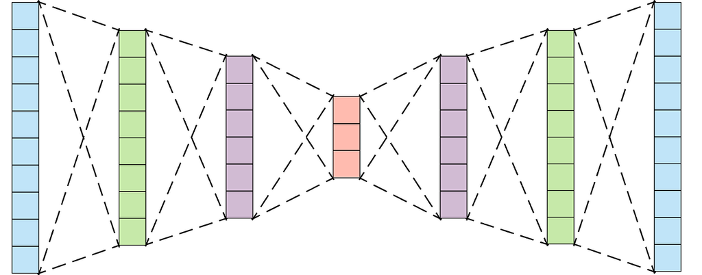

- AE jest modelem złożonym z enkodera E i dekodera D $$\begin{align} E:\mathbb{R}^m\longrightarrow\mathbb{R}^p\\ D:\mathbb{R}^p\longrightarrow\mathbb{R}^m, \end{align}$$ tak, że $x'=D(E(x))$ i $$\underset{E,D}{\arg\min}\; \mathbb{E}[L(x, x']$$ gdzie $L(\cdot,\cdot)$ jest funkcją kosztu - obrazuje jakość odtwarzania
  - jeśli traktujemy $x$ i $x'$ jako wektory bitów, albo wektory prawdopodobieństw bitów, to L może być entropią krzyżową rekonstrukcji $$L(x,x')=-\sum_{k=1}^H\left[x_k\log{x'}_k+(1-x_k)\log(1-{x'}_k)\right]$$
- **reprezentacja** jest aktywacją środkowej warstwy (bottleneck)

[figure not shown]

- generalizacja?
  - celem jest poprawne odtwarzanie danych spoza zbioru uczącego
  - AE **kompresuje** dane tak, by pozbyć się wszelkich *nieistotnych* elementów
    - nieistotne są dane rzadko spotykane, nie wpływające na obraz
    - to tzw. "stratna" kompresja, ale AE będzie potrafił usunąć szum
- efektywnie dla rozpoznawania mowy
  - przetworzony sygnał pokazywany w przesuwających się ramkach
  - reprezentacja latent dla ramek ok. 10-20 ms
  - budowa z tego odtworzonej mowy w postaci tekstu

## regularyzacja AE

- zwykle warstwa latent jest wąskim gardłem (bottleneck) dla osiągnięcia generalizacji
- **regularyzacja AE** zabezpiecza przed uczeniem się przez model funkcji identyczności
  - funkcja identyczności będzie dawać niski błąd dla przykładów uczących

### rzadkie reprezentacje

- wymuszenie by tylko część neuronów latent była aktywowana
  - typowa regularyzacja przez dodanie kosztu jako normy $L_1$ po neuronach warstwy ukrytej $$\underset{E,D}{\arg\min}\; \mathbb{E}[L(x, D(E(x))]+\lambda\sum_{k=1}^H|h_k|$$
    - może wymagać optymalizacji parametru $\lambda$
  - wykorzystać dywergencję Kulbacka-Leiblera przy założeniu, że aktywacje neuronów pochodzą z rozkładu Bernoulliego z prawdopodobieństwem $p$ $$\underset{E,D}{\arg\min}\; \mathbb{E}[L(x, D(E(x))]+\lambda\sum_{k=1}^H KL(p\|p_k)$$
    - optymalizowany jest parametr $p$
    - dywergencja $KL(P\parallel Q)$ $${\displaystyle D_{\text{KL}}(P\parallel Q)=\sum _{x\in {\mathcal {X}}}P(x)\log \left({\frac {P(x)}{Q(x)}}\right)}$$ mówi jak bardzo rozkład $P$ jest różny od $Q$
      - $KL(P \| Q)$ nie jest miarą; nie jest symetryczna i nie spełnia warunku trójkąta
      - jak wiele zyskamy używając rozkładu $P(\cdot)$ zamiast $Q(\cdot)$
    - $p_k$ jest estymowane po całym zbiorze przykładów w batchu jako $\hat{p}_k=\frac{1}{B}\sum_{i=1}^Bh_i(x)$

## Autoenkoder odszumiający (Denoising autoencoder DAE)

[[Vincent, Larochelle, Bengio, Manzagol, *Extracting and composing robust features with Denoising Autoencoders*, 2008]](https://www.cs.toronto.edu/~larocheh/publications/icml-2008-denoising-autoencoders.pdf) [[Bengio, Yao, Alain, Vincent, *Generalized Denoising Auto-Encoders as generative models*, 2013]](https://proceedings.neurips.cc/paper_files/paper/2013/file/559cb990c9dffd8675f6bc2186971dc2-Paper.pdf)

Wiarygodne uczenie jest możliwe przez uczenie się z zaszumionych danych

- odszumianie danych uczących z regularyzacja
- odtwarzanie cech z zaszumionych danych jest wiarygodne
- DAE jest algorytmem nienadzorowanym
- reprezentacje z DAE można wykorzystać do uczenia typu transfer
- idea DAE
  - niech dane $X$ będą do $\tilde{X}$ zmodyfikowane przez proces **korupcji** $q_D(\tilde{X}\mid X)$
- proces korupcji może być różny
  - odwrócenie wartości losowo wybranych bitów
  - dodanie losowego szumu
  - zadaniem DAE jest utworzenie odwrotnego mapowania $P(X\mid\tilde{X})$ przez proces uczący minimalizując $$\underset{\theta,\theta'}{\arg\min}\; \mathbb{E}_{q^0(x,x')}[L(x, g_{\theta'}(f_\theta(x'))]$$

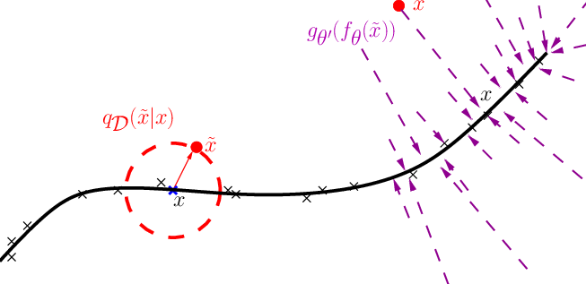

gdzie

- $q_d()$ jest procesem korupcji (np. dodanie szumu)
- $f_\theta()$ mapuje *"popsute"* wejście do reprezentacji ukrytej (enkoder)
- $g_{\theta'}$ odtwarza *"prawdziwe"* dane z utworzonej reprezentacji (dekoder)
- $q^0(X,\tilde{X})$ jest rozkładem łącznym $X$, $\tilde{X}$, i reprezentacji ukrytej $f_\theta(\tilde{X})$
- DAE *nie może* nauczyć się funkcji identyczności!
- proces uczenia z szumem i regularyzacja są równoważne dla małego addytywnego szumu
  - jednak DAE potrafi coś więcej: jest to proces wypełniania wartości brakujących
- na DAE można spojrzeć z perspektywy **uczenia rozmaitości** (manifold learning)
  - algorytm uczy się $p(X\mid\tilde{X})$ czyli mapowania $\tilde{X}$ na $X$
  - przykłady z szumem będą odległe od rozmaitości w której okolicach leżą nienaruszone dane
  - $p(X\mid\tilde{X})$ uczy się przejść z obszaru punktów $\tilde{X}$ o niskich prawdopodobieństwach do prawdopodobieństw wysokich punktów $X$ blisko manifoldu
  - $H=f(X)$ jest reprezentacją $X$, która dobrze przechowuje istotne wariancje danych na manifoldzie

## auto-enkoder kontrastowy

- celem DAE jest uniezależnienie od niedużych szumów w wejściowym wektorze
- w modelu kontrastowym celem jest uniezależnienie od małych modyfikacji wektora cech $$\underset{E,D}{\arg\min}\; \mathbb{E}[L(x, D(E(x))]+\lambda\|J_E(x)\|_2^2$$ gdzie $J_E(x)$ jest Jakobianem: macierzą gradientów cech ukrytych względem wejścia $J_{ij}=\nabla_{x_i}h_i(x_i)$
  - minimalizacja normy Jakobianu powoduje, że elementy wektora cech stają się podobne do siebie
    - Jakobian jest ortogonalny do punktu na uczonym manifoldzie
      - dodanie go jako kosztu będzie **penalizować** odchodzenie od niego
    - powoduje, że cechy mało istotne będą usuwane z modelu, cechy istotne pozostaną

## auto-enkoder z wykorzystaniem modelu RBM [[Hinto, Salakhutdinow, *Reducing the dimensionality of data with neural networks*, Science 2006]](https://www.cs.toronto.edu/~hinton/absps/science.pdf)

- liniową metodą redukcji może być PCA

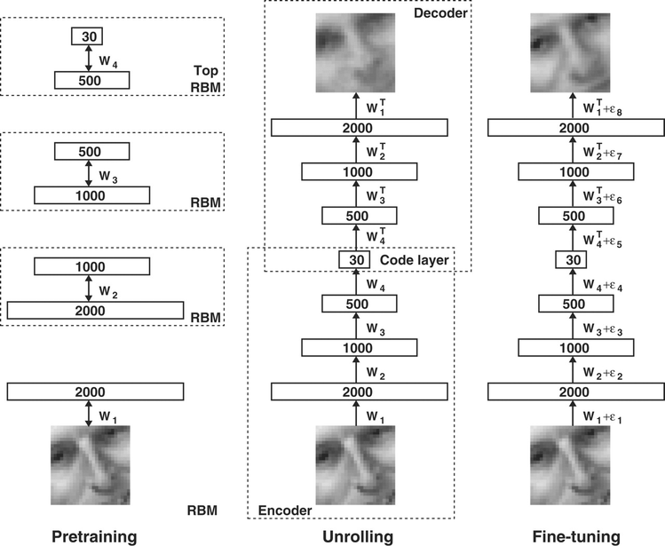

- efektywne uczenie AE z wykorzystaniem SGD bedzie uzależnione od inicjalizacji
  - zależy też od funkcji aktywacji
- **Restricted Boltzmann Machine RBM** dla wyszukania dobrej inicjalizacji
  - RBM to **energy based model EBM**
    - dla każdego stanu zdefiniowana **energia** dla
    - *"widzialnych"* neuronów (cech) $v_i$
    - *"cech"* (ukrytych) $h_j$
    - wag $w_{ij}$ i biasów $b_i, b_j$ $$E(v,h)=-\sum_{i\in\mathrm{pixels}}b_iv_i-\sum_{j\in\mathrm{features}}b_jv_j-\sum_{i,j}v_ih_jw_{ij}$$ wagi są **symetryczne**
  - w każdym kroku model minimalizuje energię przez modyfikację $$\Delta{}w_{ij}=\epsilon\left(\langle{}v_i h_j\rangle_{data} - \langle{}v_ih_j\rangle_{reconstruction}\right)$$
- uczenie w dwóch etapach

[figure not shown]

  - **świadomym**
    - warstwa widzialna jest inicjowana na przykład
    - obliczana warstwa ukryta
    - z powrotem warstwa widzialna
    - aż do osiągnięcia stanu stabilności, wtedy modyfikowane wagi
  - **marzeń sennych**
    - warstwa widzialna inicjowana losowo
    - aktywacje obliczane do osiągnięcia stanu stabilnego
  - praktycznie wystarcza jeden przebieg: widzialna -> ukryta -> widzialna
- uczenie modelu dla redukcji wymiarowości
  - **pretrenowanie** uczenie pierwszej warstwy, uzyskane reprezentacje stają się *"widzialnymi"* dla drugiej pary warstw
  - **rozwinięcie** w enkoder-dekoder
  - **tuning** przez uczenie gradientowe

## reprezentacje tokenów słów dla modeli językowych RNN

- "podobne" słowa powinny mieć podobne reprezentacje i więcej
  - *Rzym*, *Paryż*, *Berlin*, *Ateny*, *Pekin*, *Praga* powinny mieć "podobne" reprezentacje jako miasta
  - podobnie "Włochy*, "Francja*, "Niemcy", "Grecja*, *Chiny*, *Czechy* powinny być niedaleko
  - na dodatek wszystkie te miasta powinny być oddalone od odpowiadających państw podobnie, aby *Francja* - *Paryż* = *Czechy* - *Praga*
    - to pozwoli nawet na znalezienie stolicy przez *Berlin* - *Niemcy* + *Polska*...

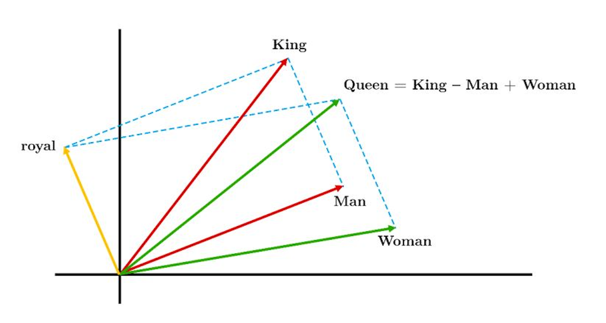

- można znaleźć przez Word2Vec [[Mikolov, Sutskever, Chen, Corrado, Dean, _Distributed representations of words and phrases and their compositionality 2013]](https://proceedings.neurips.cc/paper_files/paper/2013/file/9aa42b31882ec039965f3c4923ce901b-Paper.pdf)
  - Google w 2015 otrzymał patent na metodę, chociaż w 2014 Mikolov przeniósł się z Googla do Facebooka 😏
  - **Word2Vec** wykorzystuje dwa alternatywne podejścia z wykorzystaniem sieci neuronowej bez warstw ukrytych
    - **CBOW** na podstawie słów z lewego i prawego kontekstu przewiduje słowo pomiedzy
    - **skip gram** odwrotnie, na podstawie słowa w środku przewiduje kontekst
  - w obu przypadkach wykorzystywanym embeddingiem są wagi
  - także **GloVe**